# Assignment 2

Sarah Fondots

February 11, 2019

### Regression Analysis

This dataset of size n=51 are the 50 states and the District of Columbia in the United States from the year 2002. The variables are:

- Birth rate per 1000 females 15-17 years old
- Birth rate per 1000 females 18-19 years old
- Violent crime rate per 100,000 citizens
- Teen birth rate per 1000 births
- Poverty rate (% of the state’s population living in households with incomes below the federally defined poverty level)

We will consider the poverty rate to be the predictor(x) for teen birth rate (y).

1.First, create a scatterplot for teen birth rate vs. poverty rate. Describe the relationship that is exhibited on the graph. Identify any outliers, possible curvature.

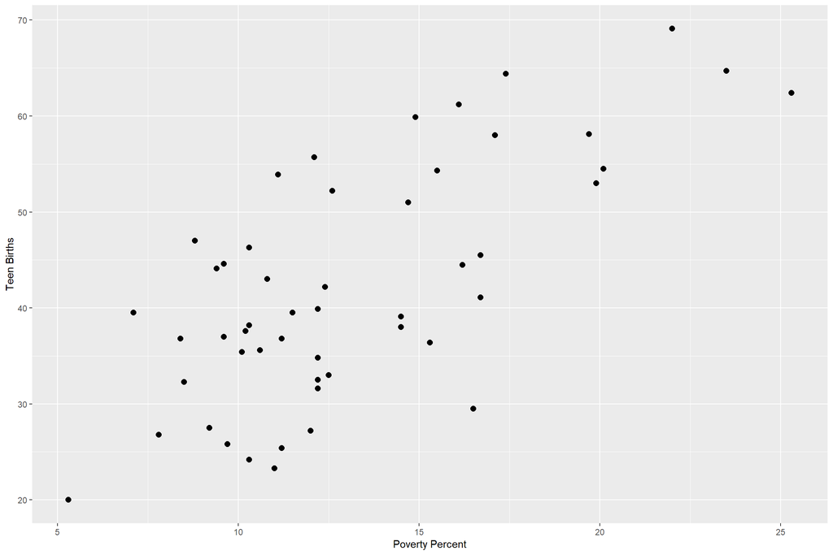

This graph seems to have a positive linear relationship between poverty and teen birth rate.

2. Next, calculate the linear correlation coefficient. Report the value of *r* under the graph.

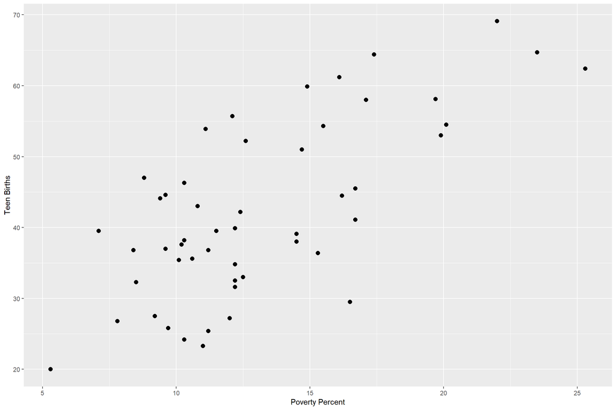

*r* = 0.7033

3. Finally, calculate the least squares model. Assess the model for its usefulness in predicting and estimating teen birth rate using the poverty rate. To assess, use the values of R<sup>2</sup> and CV.

$R^2$ = 0.4946

5. Create a scatterplot with prediction confidence bands around the regression line.

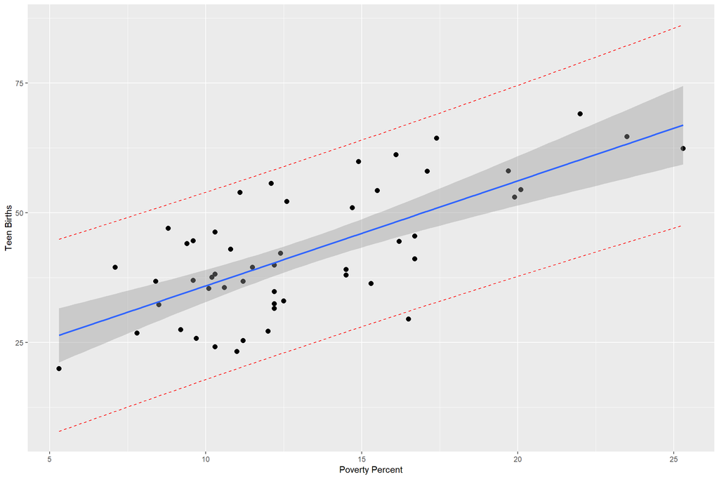